# Tidy Tuesday

## Welcome to my TidyTuesday Exercise. This week focuses on cleaning and exploring paper authorship data from the NBER.

#### Load needed packages.

```r
library(tidyverse)
library(tidyr)
library(dplyr)
library(readr)
library(here)
```

#### Load the TidyTuesday Data

```r
papers <- readr::read_csv('https://raw.githubusercontent.com/rfordatascience/tidytuesday/master/data/2021/2021-09-28/papers.csv')
authors <- readr::read_csv('https://raw.githubusercontent.com/rfordatascience/tidytuesday/master/data/2021/2021-09-28/authors.csv')
programs <- readr::read_csv('https://raw.githubusercontent.com/rfordatascience/tidytuesday/master/data/2021/2021-09-28/programs.csv')
paper_authors <- readr::read_csv('https://raw.githubusercontent.com/rfordatascience/tidytuesday/master/data/2021/2021-09-28/paper_authors.csv')
paper_programs <- readr::read_csv('https://raw.githubusercontent.com/rfordatascience/tidytuesday/master/data/2021/2021-09-28/paper_programs.csv')
```

#### Initial cleaning from Tidy Tuesday Repo. This basically joins excel files containing separate sets of variables into one chart. From here, whe can take a wholistic look at the data and see if anything is interesting.

```r
joined_df <-
  left_join(papers, paper_authors) %>%
  left_join(authors) %>%
  left_join(paper_programs) %>%
  left_join(programs)%>%
  mutate(
    catalogue_group = str_sub(paper, 1, 1),
    catalogue_group = case_when(
      catalogue_group == "h" ~ "Historical",
      catalogue_group == "t" ~ "Technical",
      catalogue_group == "w" ~ "General"
    ),
    .after = paper
  )
joined_df
```

```
## # A tibble: 130,081 x 12
##    paper catalogue_group  year month title     author name  user_nber user_repec
##    <chr> <chr>           <dbl> <dbl> <chr>     <chr>  <chr> <chr>     <chr>
##  1 w0001 General          1973     6 Educatio~ w0001~ Fini~ finis_we~ <NA>
##  2 w0002 General          1973     6 Hospital~ w0002~ Barr~ barry_ch~ pch425
##  3 w0003 General          1973     6 Error Co~ w0003~ Swar~ swarnjit~ <NA>
##  4 w0004 General          1973     7 Human Ca~ w0004~ Lee ~ <NA>      pli669
##  5 w0005 General          1973     7 A Life C~ w0005~ Jame~ james_sm~ psm28
##  6 w0006 General          1973     7 A Review~ w0006~ Vict~ victor_z~ <NA>
##  7 w0007 General          1973     8 The Defi~ w0007~ Lewi~ <NA>      <NA>
##  8 w0008 General          1973     9 Multinat~ w0008~ Merl~ <NA>      <NA>
##  9 w0008 General          1973     9 Multinat~ w0008~ Robe~ robert_l~ pli259
## 10 w0009 General          1973     9 From Age~ w0004~ Lee ~ <NA>      pli669
## # ... with 130,071 more rows, and 3 more variables: program <chr>,
## #   program_desc <chr>, program_category <chr>
```

#### We can also use the glimpse function to check outr our data sets. Since all the data is combined already, lets take a look at the joined_df.

```r
glimpse(joined_df)
```

```
## Rows: 130,081
## Columns: 12
## $ paper            <chr> "w0001", "w0002", "w0003", "w0004", "w0005", "w0006",~
## $ catalogue_group  <chr> "General", "General", "General", "General", "General"~
## $ year             <dbl> 1973, 1973, 1973, 1973, 1973, 1973, 1973, 1973, 1973,~
## $ month            <dbl> 6, 6, 6, 7, 7, 7, 8, 9, 9, 9, 9, 9, 10, 10, 10, 10, 1~
## $ title            <chr> "Education, Information, and Efficiency", "Hospital U~
## $ author           <chr> "w0001.1", "w0002.1", "w0003.1", "w0004.1", "w0005.1"~
## $ name             <chr> "Finis Welch", "Barry R Chiswick", "Swarnjit S Arora"~
## $ user_nber        <chr> "finis_welch", "barry_chiswick", "swarnjit_arora", NA~
## $ user_repec       <chr> NA, "pch425", NA, "pli669", "psm28", NA, NA, NA, "pli~
## $ program          <chr> NA, NA, NA, NA, NA, NA, NA, NA, NA, NA, NA, NA, NA, N~
## $ program_desc     <chr> NA, NA, NA, NA, NA, NA, NA, NA, NA, NA, NA, NA, NA, N~
## $ program_category <chr> NA, NA, NA, NA, NA, NA, NA, NA, NA, NA, NA, NA, NA, N~
```

### At a glance, I see that there are 130,081 observations of 12 Variables. Additionally, the most of the variables seem to be categorical, with the exception of year and month. Therefore, I think it would make sense to see how some of these catergories change from year to year or decade to decade. To narrow it down, I am going to get rid of columns I think are redundant.

#### Remove user and shorthand variables: These rows give information on author identity or provide shorthand notation of other columns. Since we have full names, these rows names aren’t useful.

```r
clean_df <-
  joined_df %>%
  select(-"user_nber", -"user_repec", -"program")

view(clean_df)
```

#### Now lets take a look at the NAs.

```r
clean_df %>%
  select(everything()) %>%
  summarise_all(funs(sum(is.na(.))))
```

```
## # A tibble: 1 x 9
##   paper catalogue_group  year month title author  name program_desc
##   <int>           <int> <int> <int> <int>  <int> <int>        <int>
## 1     0               0     0     0     0      0     0          530
## # ... with 1 more variable: program_category <int>
```

### The only NAs found are on the program description and program category variables. While they seem like large numbers, that is only about 0.4% and 1% of observations in each column. Therefore, I think its fine to keep them.

### Arbitrarily, I just wank to pick two variables to look at to see if anything interesting is going on. Let’s maybe do catalogue group over time? More specifically, let’s look at count contribution of papers to each catalouge group as a function of time in years.

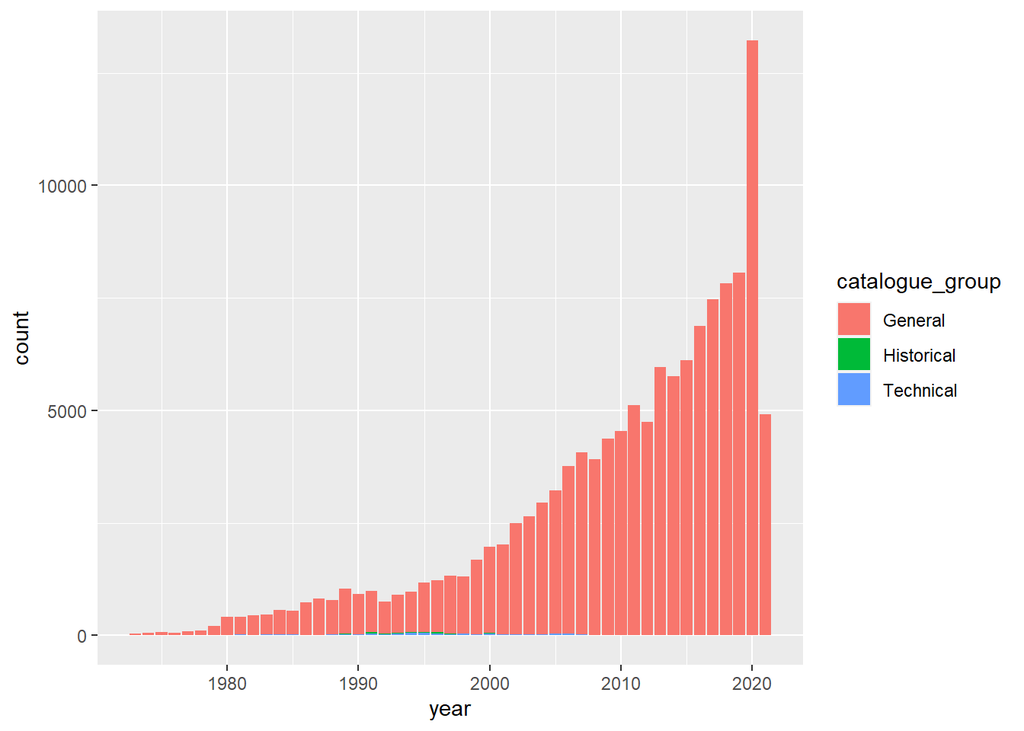

```r
catalouge_plot <- clean_df %>%
  ggplot(aes(x=year, fill=catalogue_group)) + geom_bar()

print(catalouge_plot)
```

### Interesting. First, it looks like there is somewhat of an exponential trend in number of papers written per year over time. Maybe it is a function of staff size? However, it looks like most papers are listed under the general catalogue group. This isn’t an interesting result, so we will likely not explore the catalogue group variable.

## Questions: Does the number of authors increase through time? Is there a correlation between number of authors and papers published? How efficient are these authors at producing papers?

### Obviously, you would expect number of papers to increase with increasing number of authors; more authors means more papers being produced per unit time. However, this gives us a chance to run some simple linear regression stats to see what the slope of the papers-to-authors relationship is (i.e. how efficient are these authors at writing papers).

### Let’s create data sets with number of papers through time and number of authors through time.

Create two new data that contain either authors through time or papers through time.

```r
Author_df <- clean_df %>%
  select("year", "name",)

Paper_df <- clean_df %>%
  select("year", "paper")
```

#### Let’s take a look at those new tables.

```r
glimpse(Author_df)
```

```
## Rows: 130,081
## Columns: 2
## $ year <dbl> 1973, 1973, 1973, 1973, 1973, 1973, 1973, 1973, 1973, 1973, 1973,~
## $ name <chr> "Finis Welch", "Barry R Chiswick", "Swarnjit S Arora", "Lee A Lil~
```

```r
glimpse(Paper_df)
```

```
## Rows: 130,081
## Columns: 2
## $ year  <dbl> 1973, 1973, 1973, 1973, 1973, 1973, 1973, 1973, 1973, 1973, 1973~
## $ paper <chr> "w0001", "w0002", "w0003", "w0004", "w0005", "w0006", "w0007", "~
```

#### Now we can make a bar graph of both number of authors and papers through time.

Authors

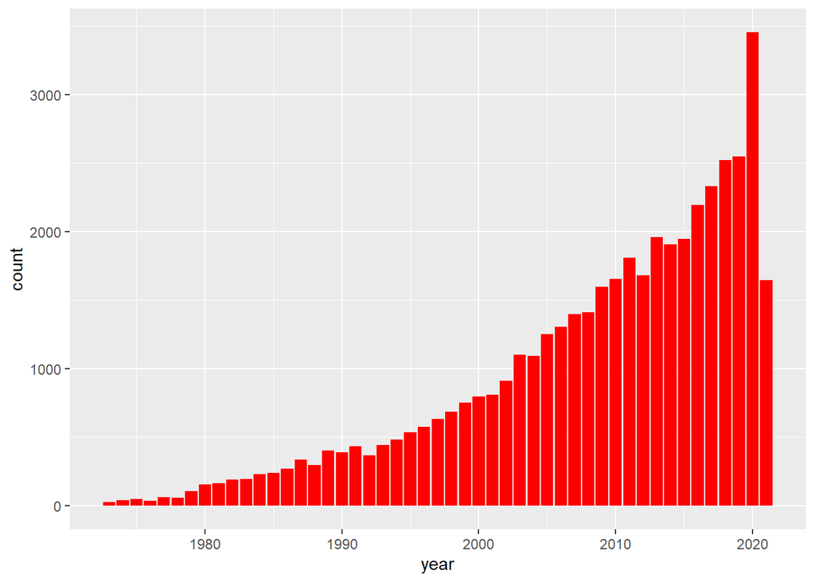

```r
Author_df <- distinct(Author_df) #Removes duplicates to avoid double counts.

Authors_plot <- Author_df %>%
  ggplot(aes(x=year)) +
  geom_bar(fill = "red")

print(Authors_plot)
```

### Okay, as predicted, the number of Authors does increase through time. Thats good for NBER, as it shows the company is growing. Now let’s plot the same chart with log(autors) to see what the linear relationship looks like.

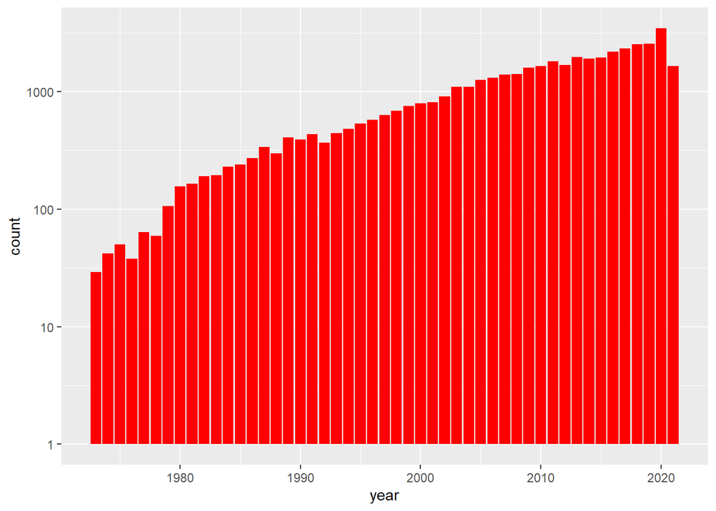

```r
log_authors_plot <- Author_df %>%
  ggplot(aes(x=year)) +
  geom_bar(fill = "red") + scale_y_continuous(trans = "log10")

print(log_authors_plot)
```

### Let’s do the same for papers over time.

Without log scale

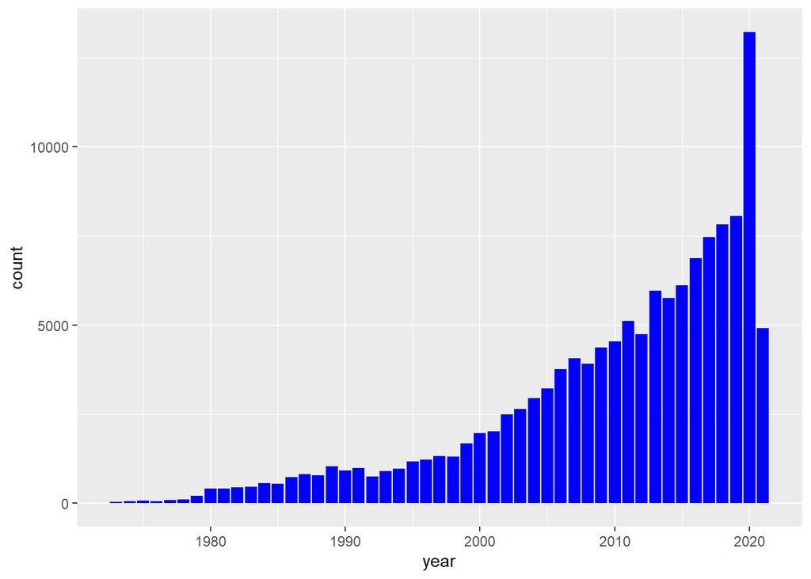

```r
papers_plot <- Paper_df %>%
  ggplot(aes(x=year)) +
  geom_bar(fill = "blue")

print(papers_plot)
```

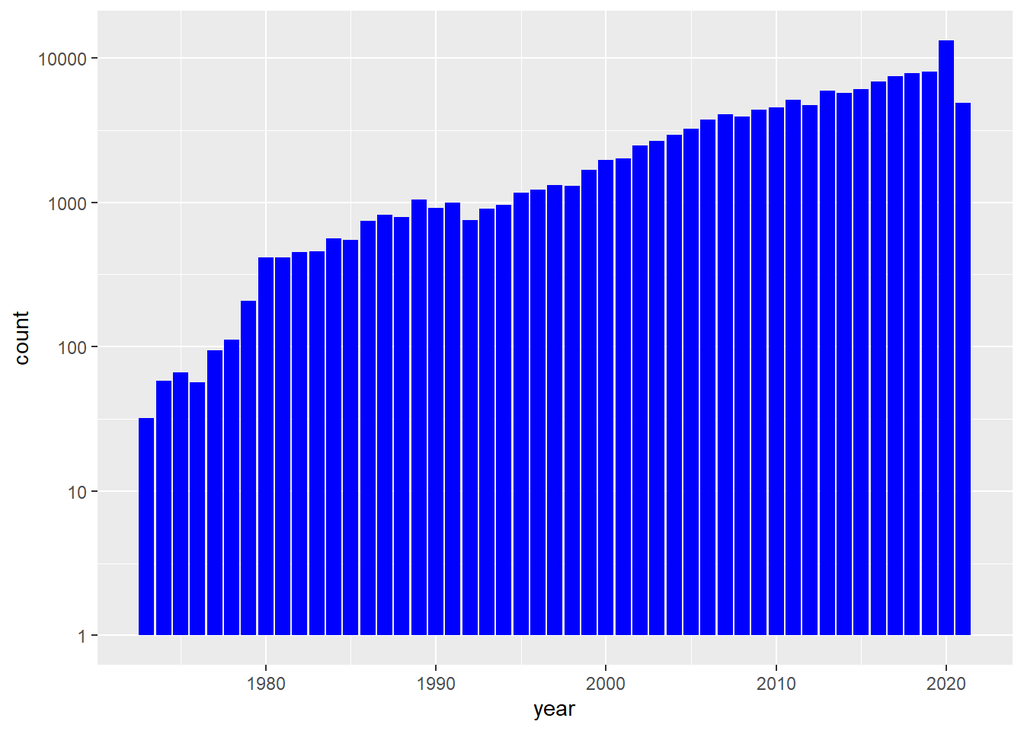

```r
log_papers_plot <- Paper_df %>%
  ggplot(aes(x=year)) +
  geom_bar(fill = "blue") + scale_y_continuous(trans = "log10")

print(log_papers_plot)
```

### Now let’s plot number of papers produced by number of authors per year

#### First we need to clean the data a bit more…. Namely creat new data frames that group the sums of both papers produced and authors by year.

Authors

```r
author_count <- as.data.frame(table(Author_df$year))

colnames(author_count) <- c("year", "count_author")

view(author_count)
```

Papers

```r
paper_count <- as.data.frame(table(Paper_df$year))

colnames(paper_count) <- c("year", "count_paper")

view(paper_count)
```

Merge together

```r
author_efficiency <- merge(author_count, paper_count, by="year")

view(author_efficiency)
```

plot

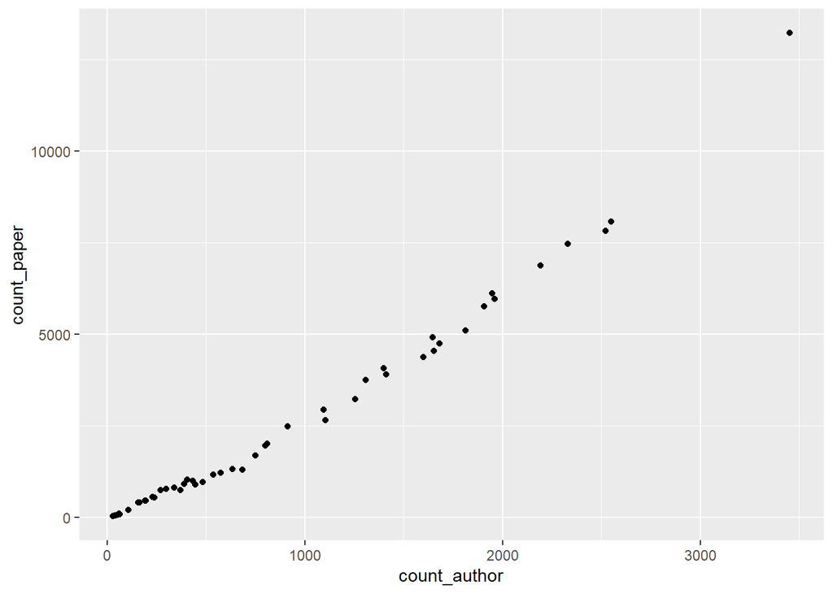

```r
efficiency_plot <- author_efficiency %>%
  ggplot(aes(x=count_author, y=count_paper)) +
  geom_point()

print(efficiency_plot)
```

Now, we are going to run a linear regression just to see what the slope is.

```r
papers_per_author <- lm(count_paper ~ count_author, data=author_efficiency)

summary(papers_per_author)
```

```
##
## Call:
## lm(formula = count_paper ~ count_author, data = author_efficiency)
##
## Residuals:
##     Min      1Q  Median      3Q     Max
## -584.27 -249.27  -37.99  249.68 2152.86
##
## Coefficients:
##                Estimate Std. Error t value Pr(>|t|)
## (Intercept)  -439.30502   93.01999  -4.723 2.13e-05 ***
## count_author    3.33144    0.07479  44.541  < 2e-16 ***
## ---
## Signif. codes:  0 '***' 0.001 '**' 0.01 '*' 0.05 '.' 0.1 ' ' 1
##
## Residual standard error: 433.1 on 47 degrees of freedom
## Multiple R-squared:  0.9769, Adjusted R-squared:  0.9764
## F-statistic:  1984 on 1 and 47 DF,  p-value: < 2.2e-16
```

#### Based on this, we are looking at, on average, about 3 papers per author since NBER’s founding.

### Finally, lets look for the year with highest per author paper production.

```r
author_efficiency <- author_efficiency %>%
  mutate(Paper_per_Author = count_paper / count_author)

view(author_efficiency)
```

Plot

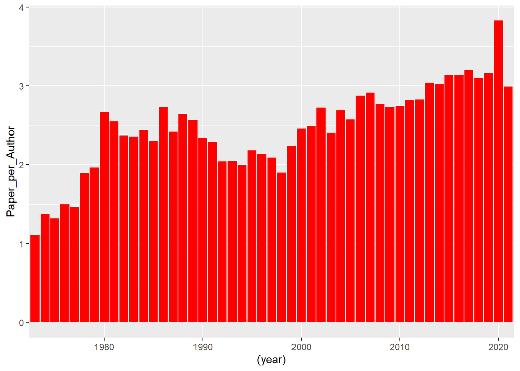

```r
per_cap_paper <- author_efficiency %>%
  ggplot(aes(x=(year), y=Paper_per_Author)) +
  geom_bar(stat = "identity", fill = "red") +
  scale_x_discrete(breaks=c("1970", "1980", "1990", "2000", "2010", "2020"))


print(per_cap_paper)
```

### This final result shows an over all incresing trend over time with a somewhat noticable dip in the 1990s and the maximum in 2020.